# Data Visualization in R

## Exercise 4:

Edit your histogram in Exercise 3. Choose an appropriate number of bins and colors.

#### Density plots

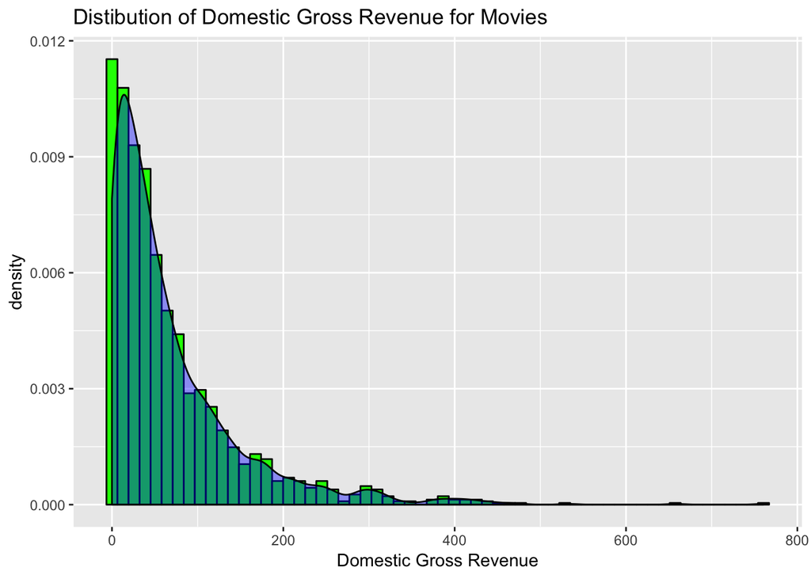

```r
# Add a density plot
ggplot(data = bech_data, aes(x = domgross, y = ..density..)) +
  geom_histogram(bins = 60, color = 'black', fill = 'green') +
  ggtitle("Distibution of Domestic Gross Revenue for Movies") +
  xlab("Domestic Gross Revenue") +
  geom_density(alpha = .4, fill = 'blue')
```

#### Histograms by group

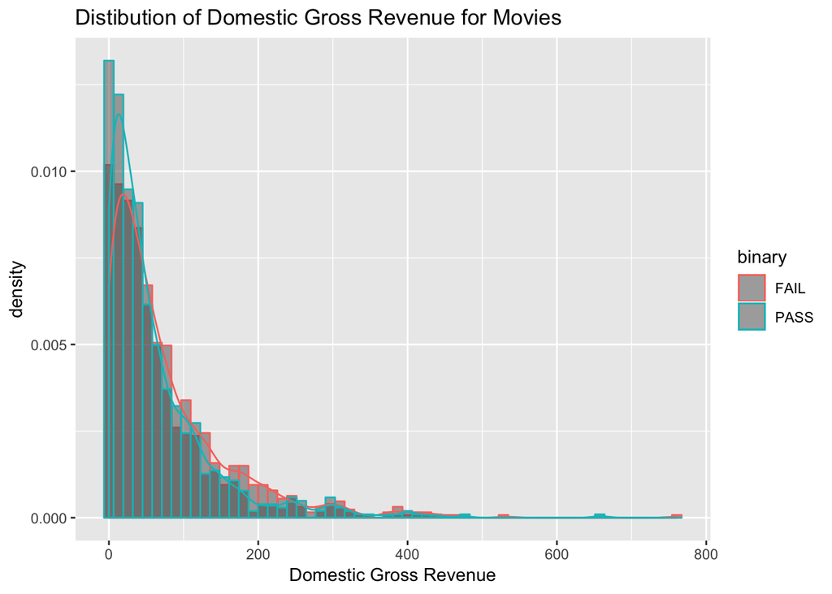

```r
# Create histograms of grouped variables
# Note: Try switching out color for fill
ggplot(data = bech_data, aes(x = domgross, y = ..density.., color = binary)) +
  geom_histogram(position = "identity", bins = 60, alpha = .5) +
  ggtitle("Distibution of Domestic Gross Revenue for Movies") +
  xlab("Domestic Gross Revenue") +
  geom_density(alpha = .4)
```

## Exercise 5:

Continue editing the histogram from Exercise 4. Now group the data by the outcome of the bechdel test and add density plots.

#### Changing legend title

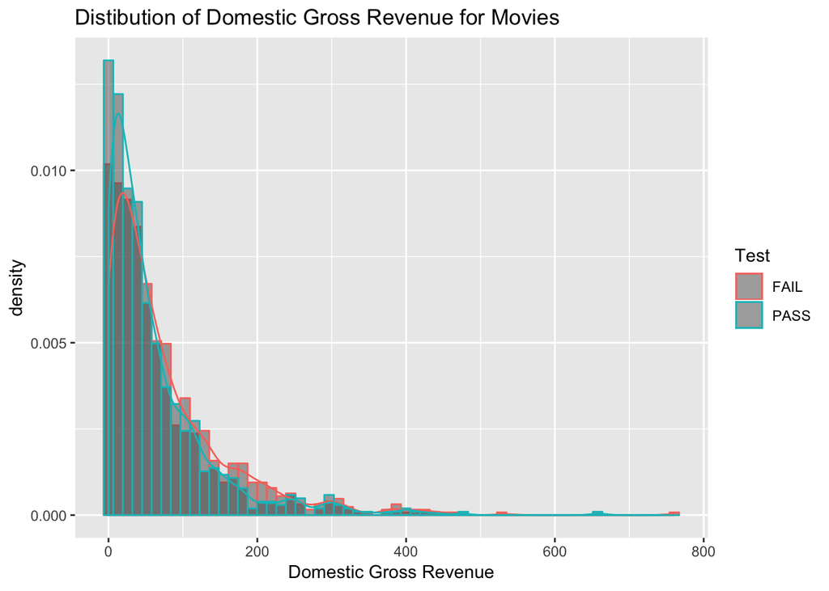

```r
# Change legend title
ggplot(data = bech_data, aes(x = domgross, y = ..density.., color = binary)) +
  geom_histogram(position = "identity", bins = 60, alpha = .5) +
  ggtitle("Distibution of Domestic Gross Revenue for Movies") +
  xlab("Domestic Gross Revenue") +
  geom_density(alpha = .4) +
  scale_color_discrete(name = "Test")
```

```r
  ggsave("Hist_Dens.png", width = 5, height = 5)
```

#### Saving Plots

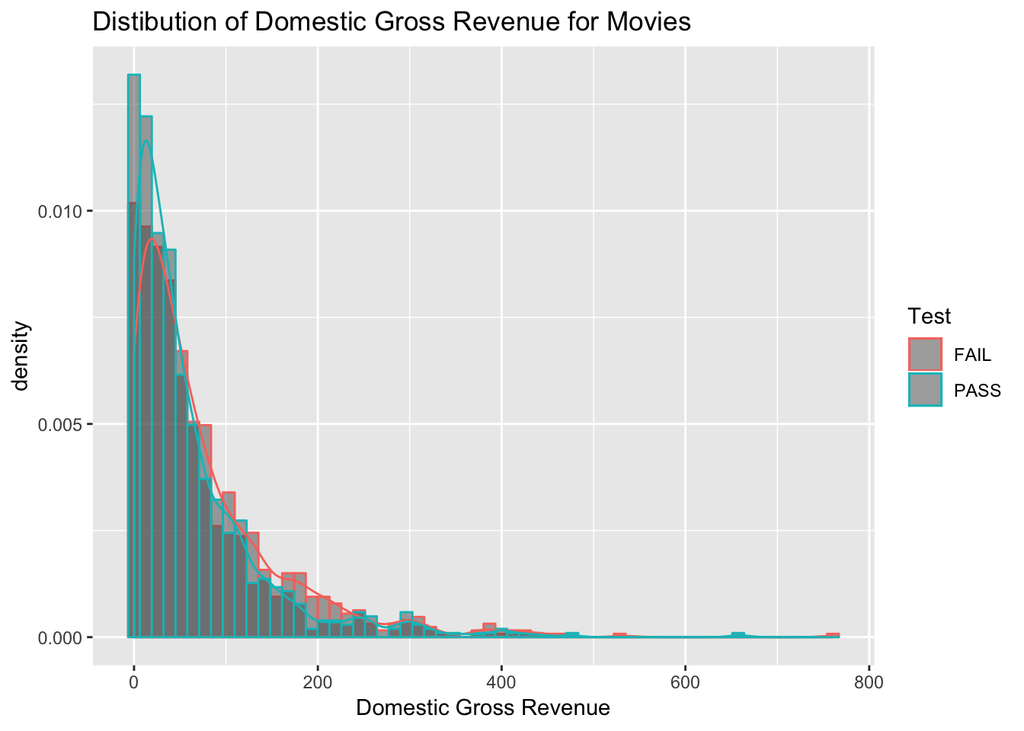

```r
# Save your plot
ggplot(data = bech_data, aes(x = domgross, y = ..density.., color = binary)) +
  geom_histogram(position = "identity", bins = 60, alpha = .5) +
  ggtitle("Distibution of Domestic Gross Revenue for Movies") +
  xlab("Domestic Gross Revenue") +
  geom_density(alpha = .4) +
  scale_color_discrete(name = "Test") +
  ggsave("Hist_Dens.png", width = 5, height = 5)
```

## Exercise 6:

Continue editing the histogram from Exercise 5. Re-title the legend and save your plot.

# Boxplot/Violin plot

These plots are used to compare distributions of data. These are especially useful for comparing different groups of continuous data.

#### Vanilla Boxplot

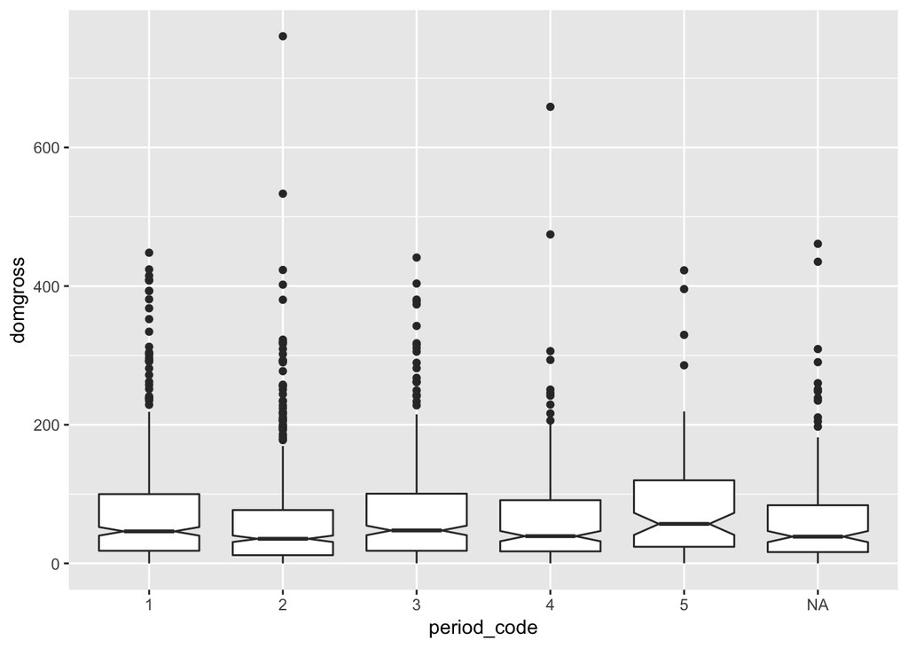

```r
# change period_code to factor so that we don't have to group
bech_data <- bech_data %>% mutate(period_code = as.factor(period_code))
# Box plot of domestic revenue by period
ggplot(data = bech_data, aes(x = period_code, y= domgross)) +
  geom_boxplot(notch = T)
```

#### Add mean to boxplot

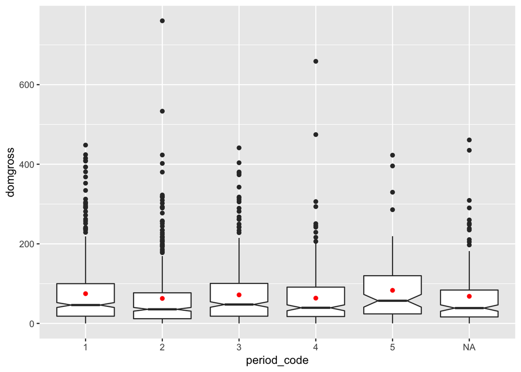

```r
# Add a red dot to represent the mean domestic revenue for each group of movies
ggplot(data = bech_data, aes(x = period_code, y = domgross)) +
  geom_boxplot(notch = T) +
  stat_summary(fun.y=mean, geom="point", color = 'red')
```

#### Color/Fill by group

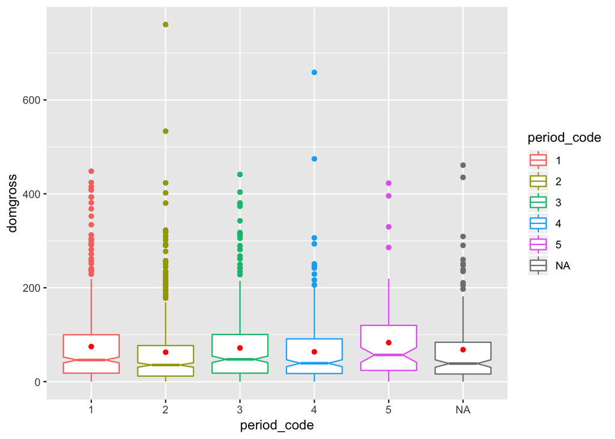

```r
# Add colors to the boxplots
ggplot(data = bech_data, aes(x = period_code, y= domgross, color = period_code)) +
  geom_boxplot(notch = T) +
  stat_summary(fun.y=mean, geom="point", color = 'red')
```

## Exercise 7:

Add a title,change the axis labels, and change the legend title to the last plot that we made.

#### Box plot with multiple groups

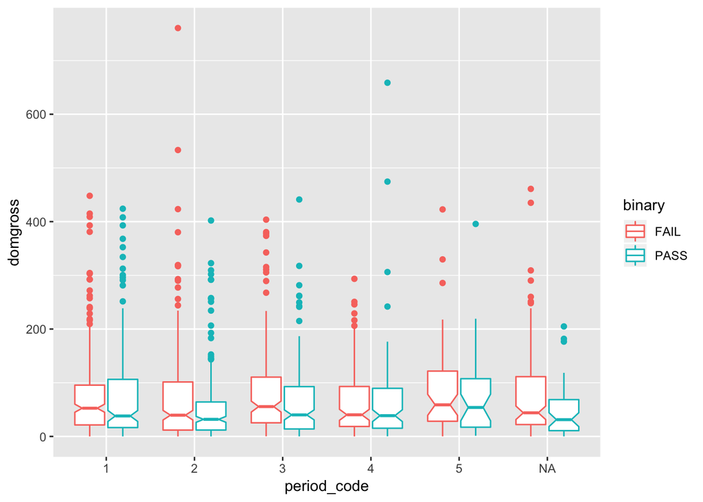

```r
# Box plot with multiple groups with color
ggplot(data = bech_data, aes(x = period_code, y= domgross, color = binary)) +
  geom_boxplot(notch = T)
```

## Exercise 8:

Instead of outlining the last boxplot in color, fill the boxplot in color. Make sure that the legend title is still changed! Use the layer “scale_fill_discrete” when “fill” is used in the aes. Use the layer “scale_color_discrete” when “color” is used in the aes.

# Scatter plot

These are useful for visualizing how two sets of continuous data are related. Let’s plot domestic gross revenue vs. international gross revenue.

#### Vanilla Scatter plot

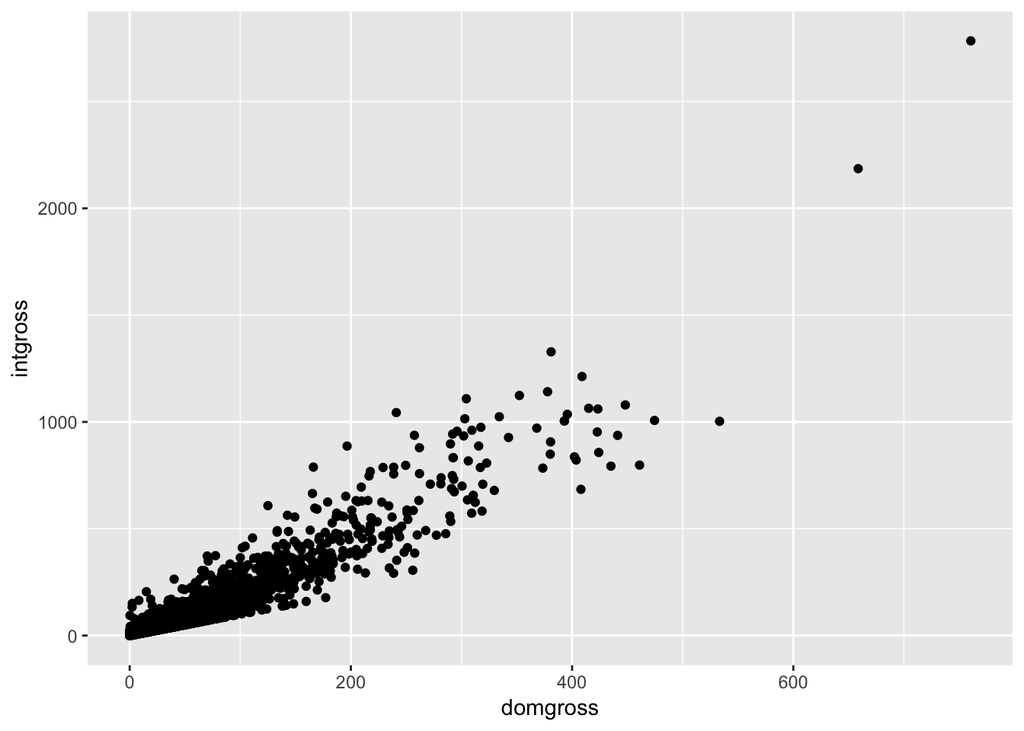

```r
# Scatter plot of domestic revenue vs. international revenue
ggplot(data = bech_data, aes(x = domgross, y = intgross)) +
  geom_point()
```

#### Change Size/Shape/Color of points

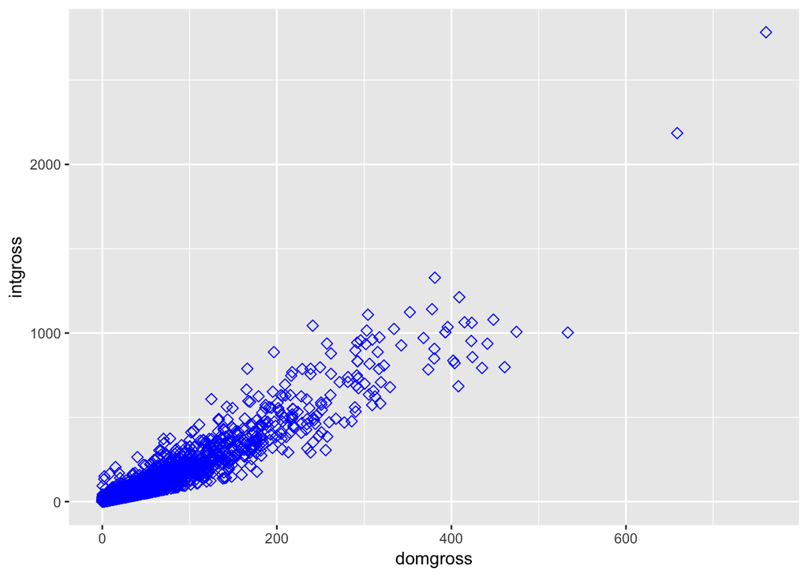

```r
# Change point size, color, and shape
ggplot(data = bech_data, aes(x = domgross, y = intgross)) +
  geom_point(size = 2, shape = 5, color = 'blue')
```

#### Label Points

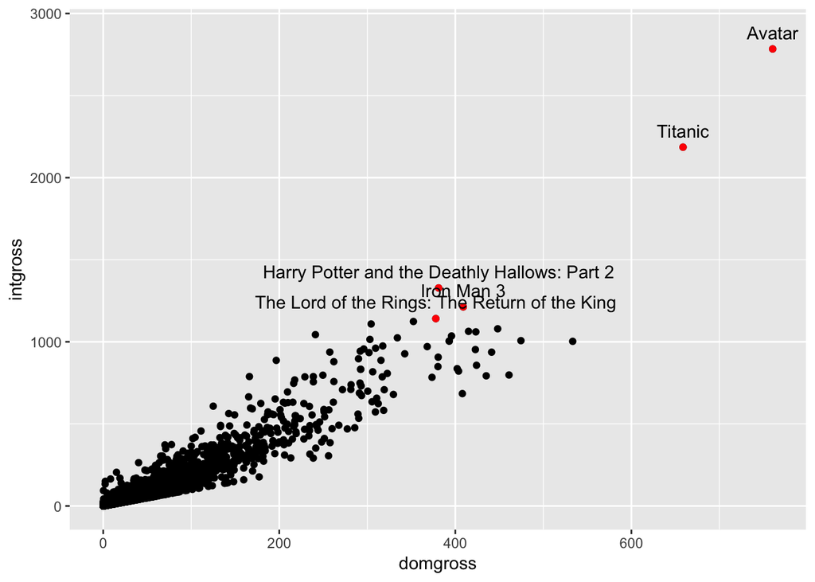

```r
# Get top 5 gorssing revenues
top5 <- bech_data %>%
  arrange(desc(intgross)) %>%
  slice(1:5)

# Bar plot of period_code reversed
ggplot(data = bech_data, aes(x = domgross, y = intgross)) +
  geom_point() +
  geom_point(data=top5, aes(x=domgross, y = intgross), color = 'red') +
  geom_text(data=top5, label = top5$title, nudge_y = 100)
```

#### Regression line

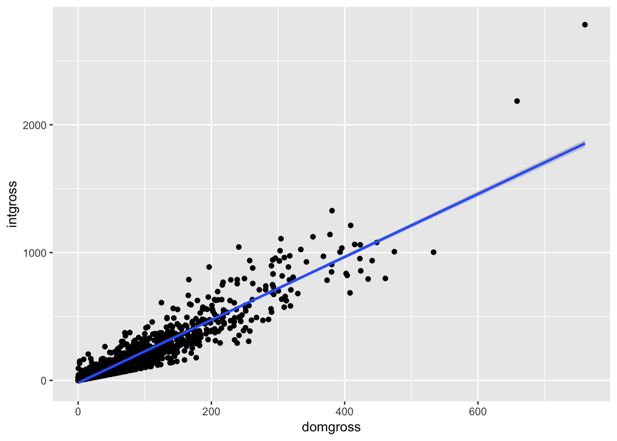

```r
# Scatter plot with regression line
ggplot(data = bech_data, aes(x = domgross, y = intgross)) +
  geom_point() +
  geom_smooth(method = 'lm', se=T)
```

## Exercise 9:

Change the color to red and linetype to dashed in the last figure.

#### Scatter plot by group

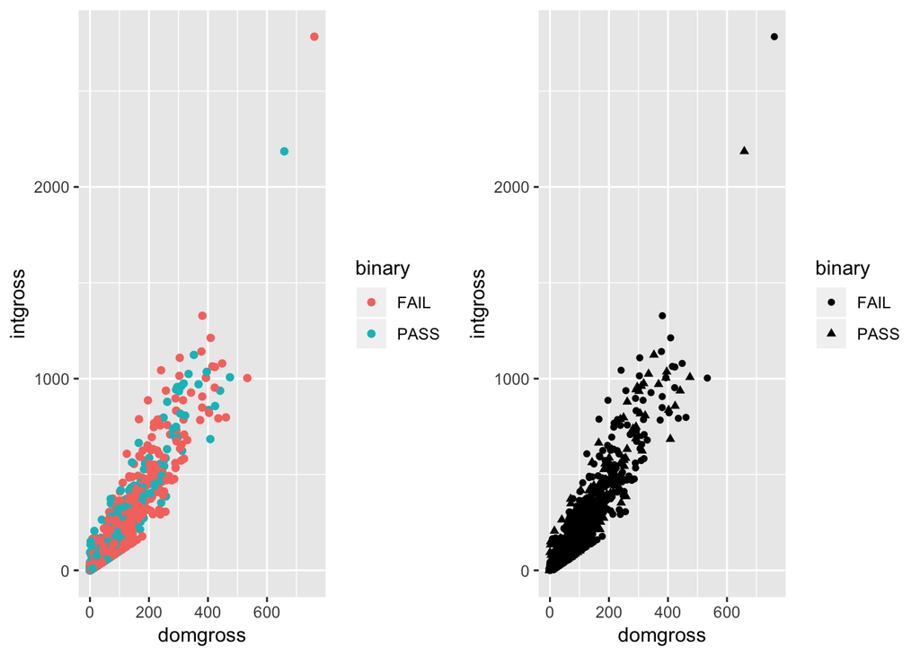

```r
# Scatter plot by group
plot1 <- ggplot(data = bech_data, aes(x = domgross, y = intgross, color = binary)) +
  geom_point()
plot2 <- ggplot(data = bech_data, aes(x = domgross, y = intgross, shape = binary)) +
  geom_point()

grid.arrange(plot1,plot2,ncol=2)
```

## Exercise 10:

Make regression lines for one of the last two scatter plots.

#### Add rugs to scatter plot

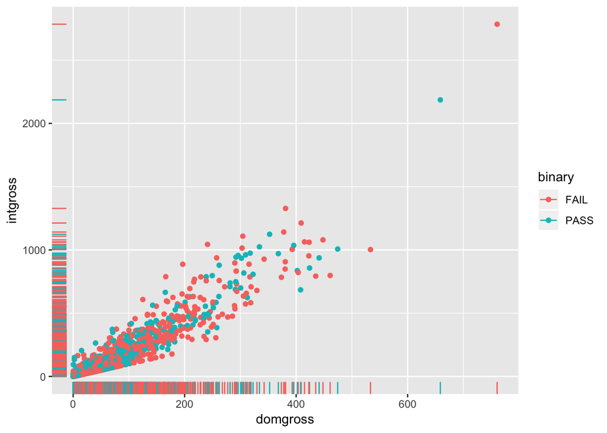

```r
# Add rugs to scatter plot
ggplot(data = bech_data, aes(x = domgross, y = intgross, color = binary)) +
  geom_point() +
  geom_rug()
```

# Other Plots

#### Bar Plots

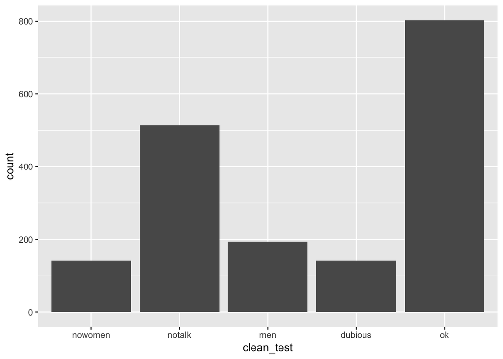

```r
# Bar plot of clean_test reversed
ggplot(data = bech_data, aes(x = clean_test)) +
  geom_bar()
```

#### Jitter Plots

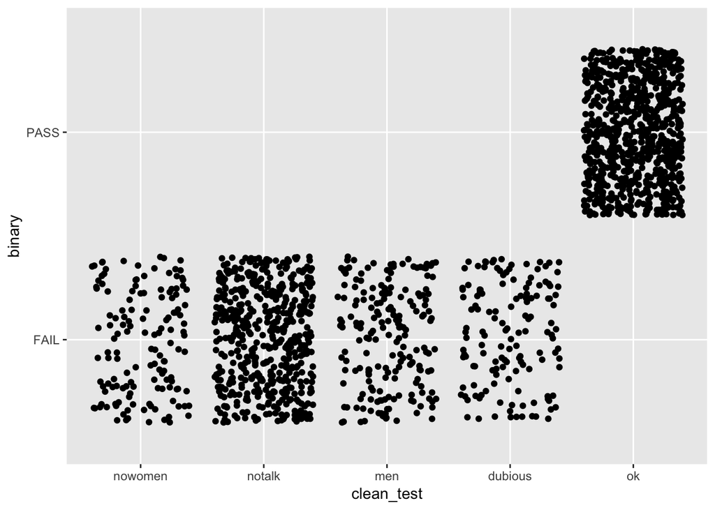

```r
# Jitter plot
ggplot(data = bech_data, aes(x = clean_test, y = binary)) +
  geom_jitter()
```

# Test Your Skills

Make some nice plots for fun.